# Spatial Analysis on Residential Real Estate Prices in California

Bonnie Yuan

12/5/2019

```r
library(mapproj)
library(plyr)
library(dplyr)
library(ggplot2)
library(leaflet)
library(sf)
library(spdep)
library(proj4)
library(maptools)
library(geoR)
library(spgwr)
library(classInt)
library(nlme)
library(pgirmess)
library(rgeos)
library(fields)
library(mgcv)
library(raster)
library(data.table)
require(foreign)
library(rgdal)
```

## Proximity: k nearest neighbor

In our study, two approaches of approximation were made: K nearest neighbor in terms of lag. County i was defined as a neighbor if it was connected within the k nearest neighbor of and j ($/w_{ij}/$=1; 0 otherwise). In our project, the kth nearest neighbor was considered as 1st 2nd and 4th nearest neighbor.

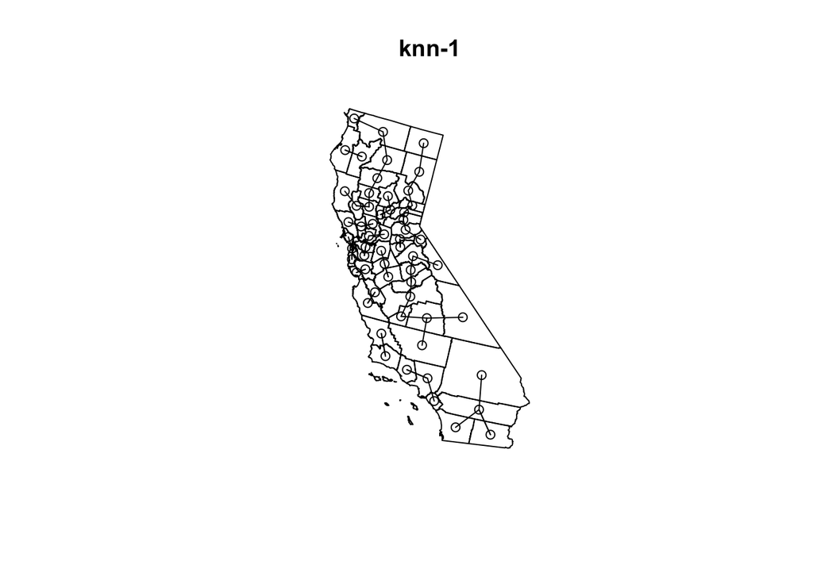

```r
nc_shp <- sf:::as_Spatial(socal$geom)
soca_coords<-data.frame(gCentroid(nc_shp,byid=TRUE))
#1-NN
ca_kn1<-knn2nb(knearneigh(coordinates(nc_shp), k=1, RANN=FALSE))
plot(nc_shp, main="knn-1")
plot(ca_kn1, coordinates(nc_shp), add=TRUE,col="black")
```

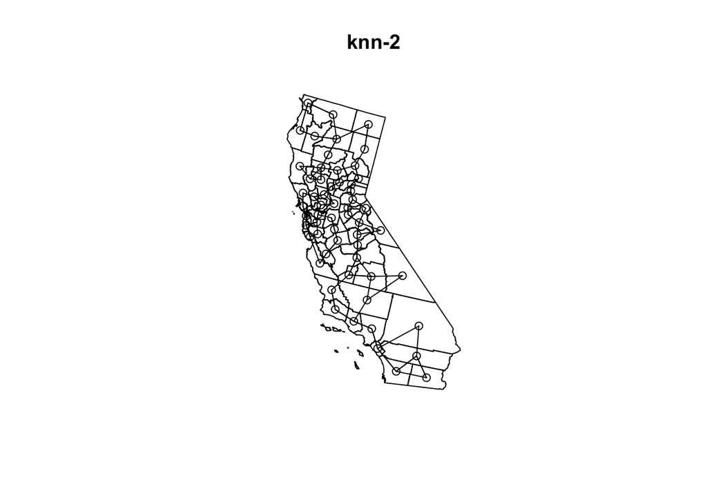

```r
#2-NN
ca_kn2<-knn2nb(knearneigh(coordinates(nc_shp), k=2, RANN=FALSE))
plot(nc_shp, main="knn-2")
plot(ca_kn2, coordinates(nc_shp), add=TRUE,col="black")
```

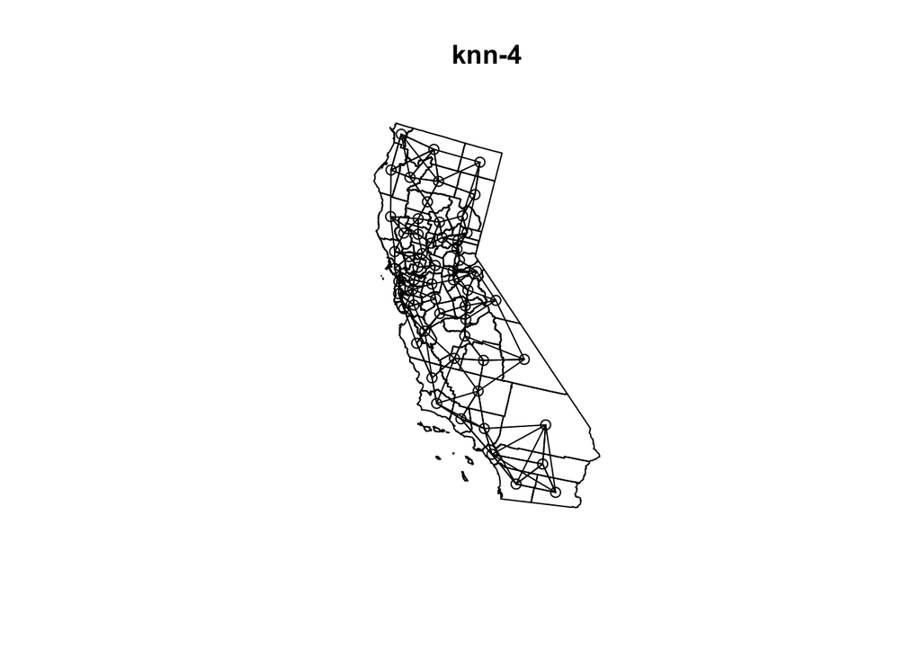

```r
#4-NN
ca_kn4<-knn2nb(knearneigh(coordinates(nc_shp), k=4, RANN=FALSE))
plot(nc_shp, main="knn-4")
plot(ca_kn4, coordinates(nc_shp), add=TRUE,col="black")
```

## Weights and the Adjacency Matrix: Row standardized

Weight plays an important role in examining spatial autocorrelation. Generally, the weights express as n*n matrix W among n observations. As shown below, each element 𝜔"# in the W matrix is seen as spatial weights:

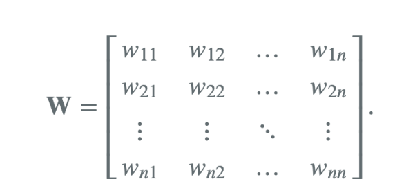

There are two ways of obtaining weight matrix: binary, and row standardized weight matrix. Binary defines weights 1 as neighboring features and 0 to all other features. While row standardized weight matrix takes given weights 𝜔"# and divides them by the row sum: $/w_{ij}(s)=\frac{w_{ij}}{\sum w_{ij}}$. This method ensures that all weights are between 0 and 1: $/s=\sum_{i}\sum_{j} w_{ij}$, which makes the neighboring values better to interpret. Therefore, in this project. Row standardized was used in this project.

```r
#4NN-Row Standardized
ca_kn1_ww<-nb2listw(ca_kn1, style="W")
ca_kn1_ww
```

```
## Characteristics of weights list object:
## Neighbour list object:
## Number of regions: 58
## Number of nonzero links: 58
## Percentage nonzero weights: 1.724138
## Average number of links: 1
## Non-symmetric neighbours list
##
## Weights style: W
## Weights constants summary:
##    n   nn S0 S1  S2
## W 58 3364 58 88 264
```

```r
summary(unlist(ca_kn1_ww$weights))
```

```
##    Min. 1st Qu.  Median    Mean 3rd Qu.    Max.
##       1       1       1       1       1       1
```

```r
#4NN-Row Standardized
ca_kn2_ww<-nb2listw(ca_kn2, style="W")
ca_kn2_ww
```

```
## Characteristics of weights list object:
## Neighbour list object:
## Number of regions: 58
## Number of nonzero links: 116
## Percentage nonzero weights: 3.448276
## Average number of links: 2
## Non-symmetric neighbours list
##
## Weights style: W
## Weights constants summary:
##    n   nn S0 S1    S2
## W 58 3364 58 51 248.5
```

```r
summary(unlist(ca_kn2_ww$weights))
```

```
##    Min. 1st Qu.  Median    Mean 3rd Qu.    Max.
##     0.5     0.5     0.5     0.5     0.5     0.5
```

```r
#4NN-Row Standardized
ca_kn4_ww<-nb2listw(ca_kn4, style="W")
ca_kn4_ww
```

```
## Characteristics of weights list object:
## Neighbour list object:
## Number of regions: 58
## Number of nonzero links: 232
## Percentage nonzero weights: 6.896552
## Average number of links: 4
## Non-symmetric neighbours list
##
## Weights style: W
## Weights constants summary:
##    n   nn S0    S1      S2
## W 58 3364 58 25.75 237.875
```

## Model selection for predictor variables

### Spatial Association-global

#### Moran’s I:

The results showed that there were significant spatial autocorrelations for both Median gross rent and Median house values using 1nn, 2nn, and 4nn row standardized weights. We noticed that for the same variable when we increased the knn number the Moran’s I statistics decreased so the magnitude of autocorrelation decreased. Giving the result, 1NN had better results indicating the strongest spatial autocorrelation.

[figure not shown]

```r
#1NN-Row Standardized
moran1<-moran.test(socal$median.gross.rent,ca_kn1_ww)
moran1
```

```
##
##  Moran I test under randomisation
##
## data:  socal$median.gross.rent
## weights: ca_kn1_ww
##
## Moran I statistic standard deviate = 5.0208, p-value = 2.572e-07
## alternative hypothesis: greater
## sample estimates:
## Moran I statistic       Expectation          Variance
##        0.78388020       -0.01754386        0.02547843
```

```r
moran2<-moran.test(socal$median.house.values,ca_kn1_ww)
moran2
```

```
##
##  Moran I test under randomisation
##
## data:  socal$median.house.values
## weights: ca_kn1_ww
##
## Moran I statistic standard deviate = 5.9093, p-value = 1.718e-09
## alternative hypothesis: greater
## sample estimates:
## Moran I statistic       Expectation          Variance
##        0.91175966       -0.01754386        0.02473132
```

```r
moran3<-moran.test(socal$median.gross.rent,ca_kn2_ww)
moran3
```

```
##
##  Moran I test under randomisation
##
## data:  socal$median.gross.rent
## weights: ca_kn2_ww
##
## Moran I statistic standard deviate = 6.5396, p-value = 3.085e-11
## alternative hypothesis: greater
## sample estimates:
## Moran I statistic       Expectation          Variance
##        0.77049909       -0.01754386        0.01452122
```

```r
moran4<-moran.test(socal$median.house.values,ca_kn2_ww)
moran4
```

```
##
##  Moran I test under randomisation
##
## data:  socal$median.house.values
## weights: ca_kn2_ww
##
## Moran I statistic standard deviate = 6.9251, p-value = 2.179e-12
## alternative hypothesis: greater
## sample estimates:
## Moran I statistic       Expectation          Variance
##        0.80462178       -0.01754386        0.01409513
```

```r
moran5<-moran.test(socal$median.gross.rent,ca_kn4_ww)
moran5
```

```
##
##  Moran I test under randomisation
##
## data:  socal$median.gross.rent
## weights: ca_kn4_ww
##
## Moran I statistic standard deviate = 8.0451, p-value = 4.309e-16
## alternative hypothesis: greater
## sample estimates:
## Moran I statistic       Expectation          Variance
##       0.657664617      -0.017543860       0.007043904
```

```r
moran6<-moran.test(socal$median.house.values,ca_kn4_ww)
moran6
```

```
##
##  Moran I test under randomisation
##
## data:  socal$median.house.values
## weights: ca_kn4_ww
##
## Moran I statistic standard deviate = 8.255, p-value < 2.2e-16
## alternative hypothesis: greater
## sample estimates:
## Moran I statistic       Expectation          Variance
##       0.665021665      -0.017543860       0.006836887
```

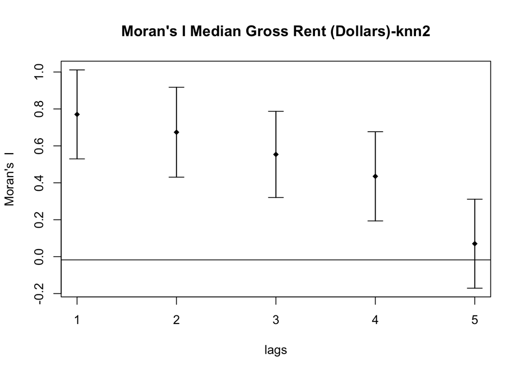

```r
corrneigh1<-sp.correlogram(ca_kn2,socal$median.gross.rent, order=5, method="I", zero.policy=TRUE)
plot(corrneigh1, main="Moran's I Median Gross Rent (Dollars)-knn2")
```

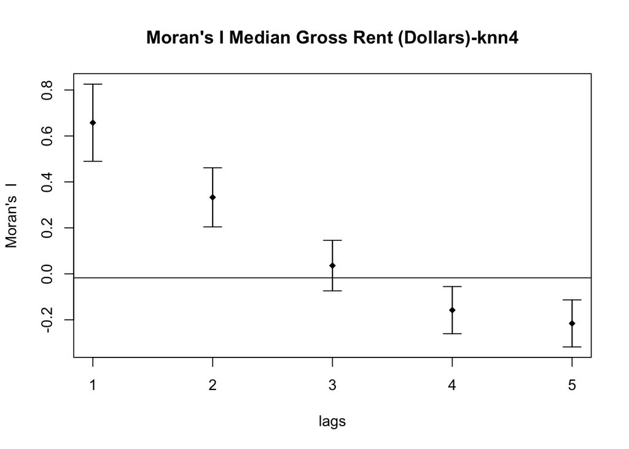

```r
corrneigh2<-sp.correlogram(ca_kn4,socal$median.gross.rent, order=5, method="I", zero.policy=TRUE)
plot(corrneigh2, main="Moran's I Median Gross Rent (Dollars)-knn4")
```

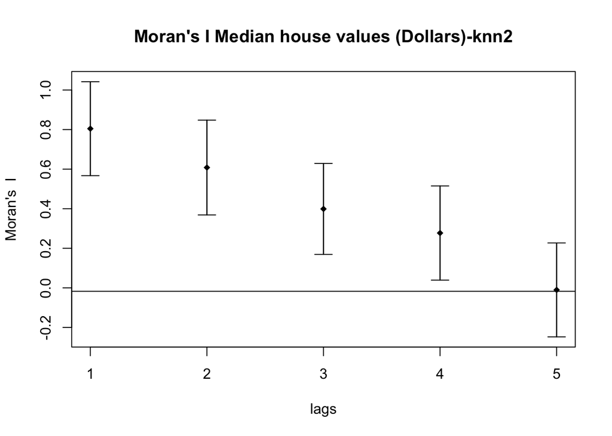

```r
corrneigh3<-sp.correlogram(ca_kn2,socal$median.house.values, order=5, method="I", zero.policy=TRUE)
plot(corrneigh3, main="Moran's I Median house values (Dollars)-knn2")
```

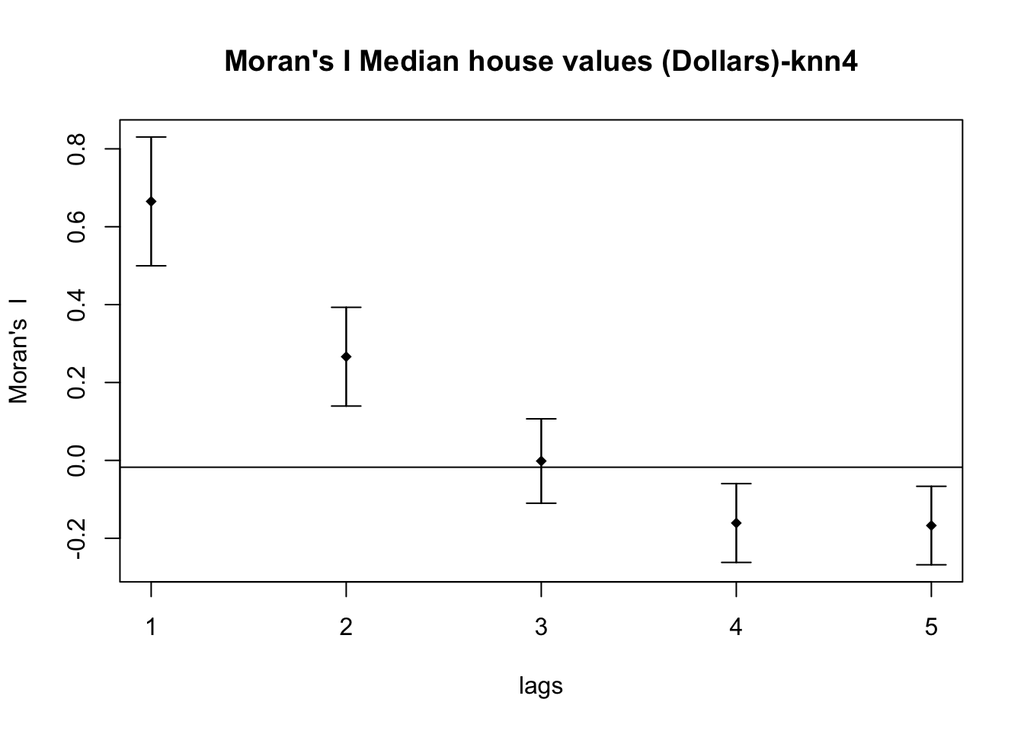

```r
corrneigh4<-sp.correlogram(ca_kn4,socal$median.house.values, order=5, method="I", zero.policy=TRUE)
plot(corrneigh4, main="Moran's I Median house values (Dollars)-knn4")
```

## Spatial Auto-Regressive Models

### local Moran’s I

Both local and global Moran’s I test under the null hypothesis that there is no spatial autocorrelation for this variable. But different from the global Moran’s I that calculates the overall spatial relationships, local Moran’s I calculates for each unit of location.

From the local Moran’s I plots we can see that similar patterns for 1NN and 2NN. Counties in western California for the median gross rent. Blue dots indicating there was significant spatial autocorrelation among those counties. As we can see that when the number of KNN increased from 1NN to 2NN, the number of blue dots in the same area increased. For 4NN, there was one more clustering effect located in southern California.

For the median house value, we can see similar patterns that high values were clustered in western California. Also, 1NN and 2NN show that the median house value in southern California has a distinct clustering effect. When the number of knn increased, the number of clustered counties were increased as well.

```r
#1. Local Moran's I for the median gross rent
moranLocmgr1<-localmoran(socal$median.gross.rent,ca_kn1_ww, p.adjust.method="bonferroni")
summary(moranLocmgr1)
```

```
##        Ii               E.Ii              Var.Ii            Z.Ii
##  Min.   :-0.3084   Min.   :-0.01754   Min.   :0.9694   Min.   :-0.2954
##  1st Qu.: 0.1765   1st Qu.:-0.01754   1st Qu.:0.9694   1st Qu.: 0.1971
##  Median : 0.5519   Median :-0.01754   Median :0.9694   Median : 0.5784
##  Mean   : 0.7839   Mean   :-0.01754   Mean   :0.9694   Mean   : 0.8140
##  3rd Qu.: 0.8757   3rd Qu.:-0.01754   3rd Qu.:0.9694   3rd Qu.: 0.9072
##  Max.   : 4.3558   Max.   :-0.01754   Max.   :0.9694   Max.   : 4.4419
##    Pr(z > 0)
##  Min.   :0.0000089
##  1st Qu.:0.3644877
##  Median :0.5630512
##  Mean   :0.5624708
##  3rd Qu.:0.8439816
##  Max.   :1.0000000
```

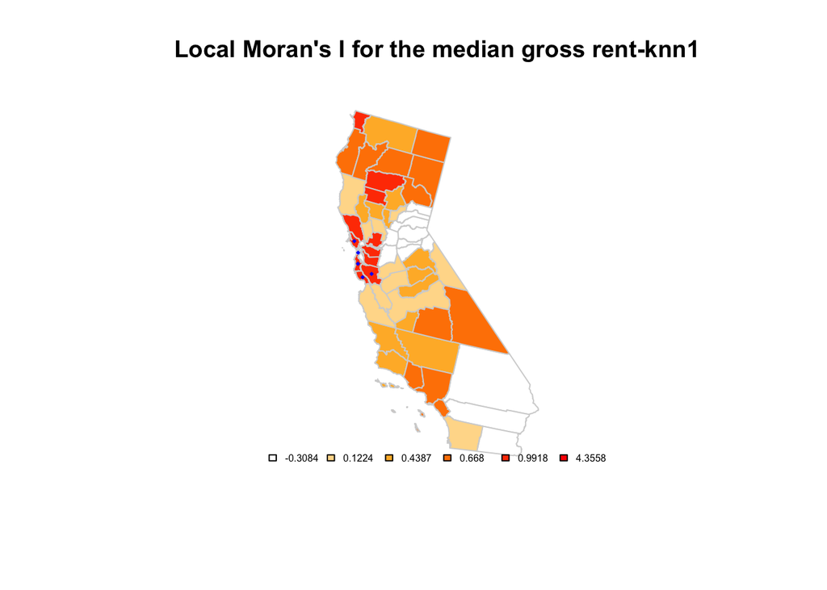

```r
socal$locM<-(moranLocmgr1[,1])
morans_breaks1 <- quantile(socal$locM,seq(0,1,1/5)) #quantile braks
col.palette <- colorRampPalette(c("white","orange", "red"), space = "rgb")
col_ramp1 <-col.palette(length(morans_breaks1))
# Statistically significant local Moran I as points
LocMoranTest = moranLocmgr1[,5]<=0.05
plot(nc_shp,border="lightgray",col=col_ramp1[findInterval(moranLocmgr1[,1],morans_breaks1,all.inside=TRUE)])
points(soca_coords[,1][LocMoranTest],soca_coords[,2][LocMoranTest], col="blue", cex=0.5, pch=18)
legend("bottom",horiz=TRUE,legend=(round(morans_breaks1,digits=4)),fill=col_ramp1,bty='n',cex=0.5)
title("Local Moran's I for the median gross rent-knn1")
```

```r
#1. Local Moran's I for the median gross rent
moranLocmgr2<-localmoran(socal$median.gross.rent,ca_kn2_ww, p.adjust.method="bonferroni")
summary(moranLocmgr2)
```

```
##        Ii                E.Ii              Var.Ii            Z.Ii
##  Min.   :-0.69164   Min.   :-0.01754   Min.   :0.4763   Min.   :-0.9767
##  1st Qu.: 0.07604   1st Qu.:-0.01754   1st Qu.:0.4763   1st Qu.: 0.1356
##  Median : 0.61851   Median :-0.01754   Median :0.4763   Median : 0.9216
##  Mean   : 0.77050   Mean   :-0.01754   Mean   :0.4763   Mean   : 1.1419
##  3rd Qu.: 0.96203   3rd Qu.:-0.01754   3rd Qu.:0.4763   3rd Qu.: 1.4194
##  Max.   : 4.05959   Max.   :-0.01754   Max.   :0.4763   Max.   : 5.9077
##    Pr(z > 0)
##  Min.   :0.0000
##  1st Qu.:0.2340
##  Median :0.5352
##  Mean   :0.5661
##  3rd Qu.:1.0000
##  Max.   :1.0000
```

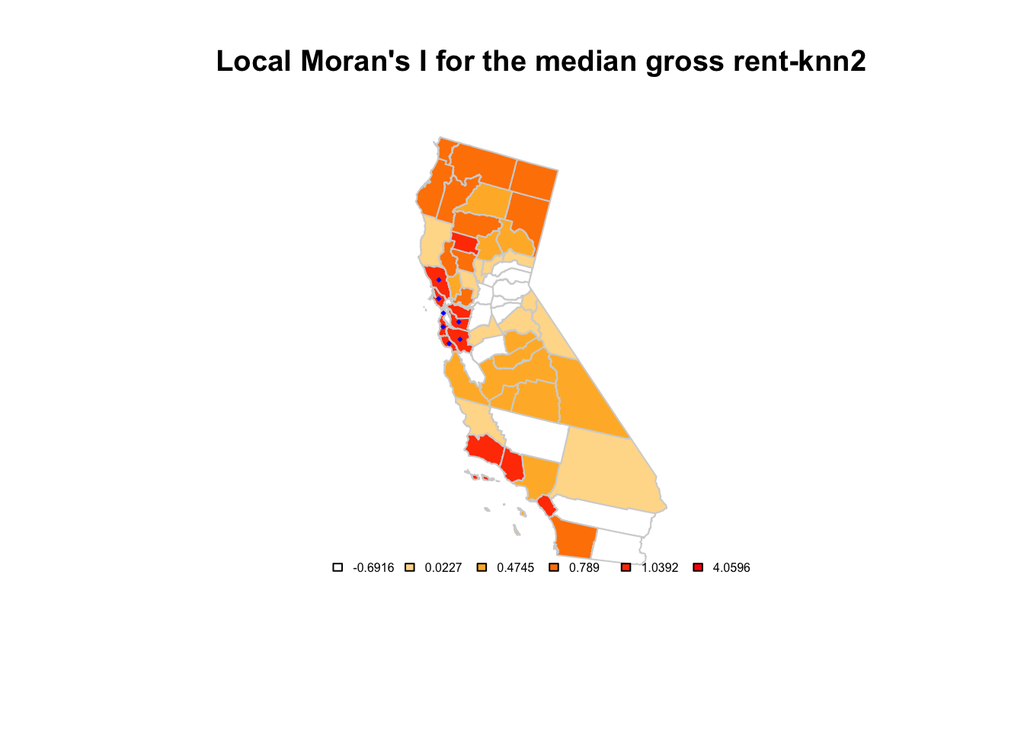

```r
socal$locM2<-(moranLocmgr2[,1])
morans_breaks2 <- quantile(socal$locM2,seq(0,1,1/5)) #quantile braks
col.palette <- colorRampPalette(c("white","orange", "red"), space = "rgb")
col_ramp2 <-col.palette(length(morans_breaks2))
# Statistically significant local Moran I as points
LocMoranTest2 = moranLocmgr2[,5]<=0.05
plot(nc_shp,border="lightgray",col=col_ramp2[findInterval(moranLocmgr2[,1],morans_breaks2,all.inside=TRUE)])
points(soca_coords[,1][LocMoranTest2],soca_coords[,2][LocMoranTest2], col="blue", cex=0.5, pch=18)
legend("bottom",horiz=TRUE,legend=(round(morans_breaks2,digits=4)),fill=col_ramp2,bty='n',cex=0.5)
title("Local Moran's I for the median gross rent-knn2")
```

```r
#1. Local Moran's I for the median gross rent
moranLocmgr3<-localmoran(socal$median.gross.rent,ca_kn4_ww, p.adjust.method="bonferroni")
summary(moranLocmgr3)
```

```
##        Ii                E.Ii              Var.Ii            Z.Ii
##  Min.   :-0.83093   Min.   :-0.01754   Min.   :0.2298   Min.   :-1.6969
##  1st Qu.: 0.09629   1st Qu.:-0.01754   1st Qu.:0.2298   1st Qu.: 0.2375
##  Median : 0.43487   Median :-0.01754   Median :0.2298   Median : 0.9438
##  Mean   : 0.65767   Mean   :-0.01754   Mean   :0.2298   Mean   : 1.4086
##  3rd Qu.: 0.94541   3rd Qu.:-0.01754   3rd Qu.:0.2298   3rd Qu.: 2.0089
##  Max.   : 4.20987   Max.   :-0.01754   Max.   :0.2298   Max.   : 8.8193
##    Pr(z > 0)
##  Min.   :0.0000
##  1st Qu.:0.1114
##  Median :0.8632
##  Mean   :0.6302
##  3rd Qu.:1.0000
##  Max.   :1.0000
```

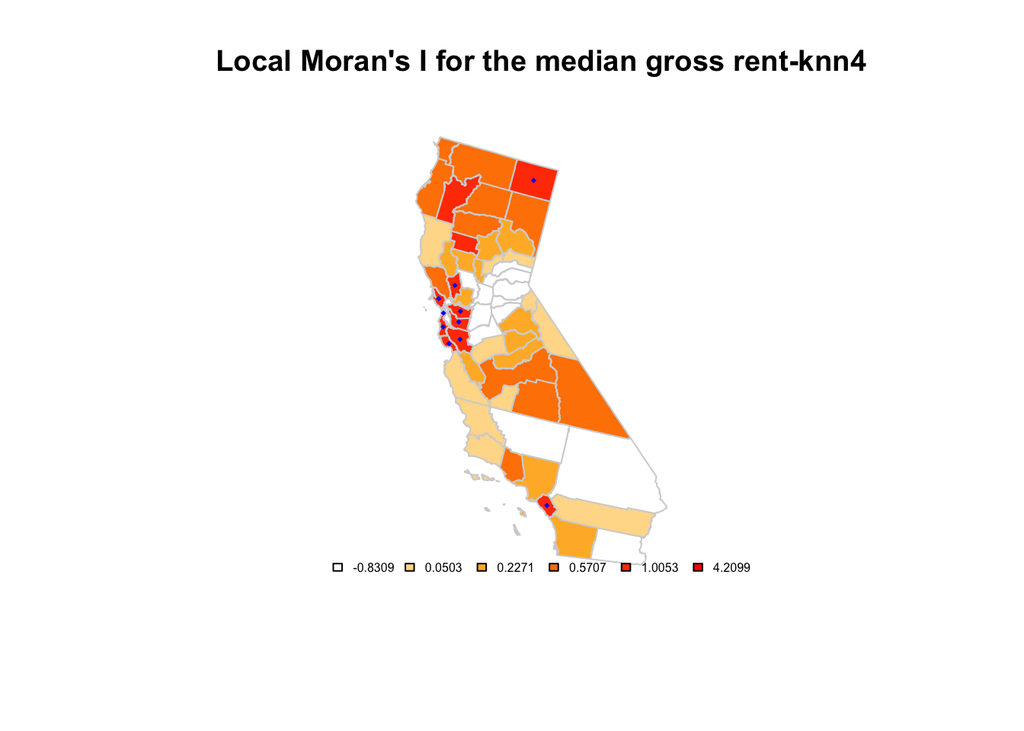

```r
socal$locM3<-(moranLocmgr3[,1])
morans_breaks3 <- quantile(socal$locM3,seq(0,1,1/5)) #quantile braks
col.palette <- colorRampPalette(c("white","orange", "red"), space = "rgb")
col_ramp3 <-col.palette(length(morans_breaks3))
# Statistically significant local Moran I as points
LocMoranTest3 = moranLocmgr3[,5]<=0.05
plot(nc_shp,border="lightgray",col=col_ramp3[findInterval(moranLocmgr3[,1],morans_breaks3,all.inside=TRUE)])
points(soca_coords[,1][LocMoranTest3],soca_coords[,2][LocMoranTest3], col="blue", cex=0.5, pch=18)
legend("bottom",horiz=TRUE,legend=(round(morans_breaks3,digits=4)),fill=col_ramp3,bty='n',cex=0.5)
title("Local Moran's I for the median gross rent-knn4")
```

```r
#2. Local Moran's I for Median house values
moranLochv1<-localmoran(socal$median.house.values,ca_kn1_ww, p.adjust.method="bonferroni")
summary(moranLochv1)
```

```
##        Ii               E.Ii              Var.Ii            Z.Ii
##  Min.   :-0.1775   Min.   :-0.01754   Min.   :0.9418   Min.   :-0.1649
##  1st Qu.: 0.1504   1st Qu.:-0.01754   1st Qu.:0.9418   1st Qu.: 0.1730
##  Median : 0.4919   Median :-0.01754   Median :0.9418   Median : 0.5250
##  Mean   : 0.9118   Mean   :-0.01754   Mean   :0.9418   Mean   : 0.9576
##  3rd Qu.: 0.6269   3rd Qu.:-0.01754   3rd Qu.:0.9418   3rd Qu.: 0.6641
##  Max.   : 8.0845   Max.   :-0.01754   Max.   :0.9418   Max.   : 8.3488
##    Pr(z > 0)
##  Min.   :0.0000
##  1st Qu.:0.5066
##  Median :0.5996
##  Mean   :0.6166
##  3rd Qu.:0.8627
##  Max.   :1.0000
```

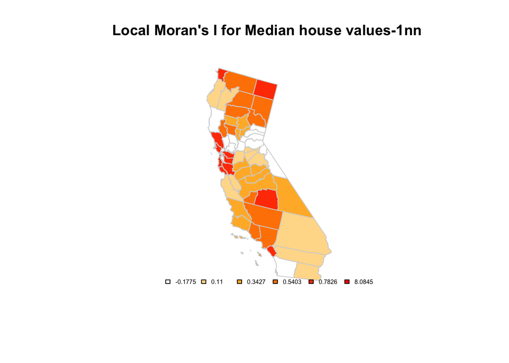

```r
socal$locM1<-(moranLochv1[,1])
morans_breaks1 <- quantile(socal$locM1,seq(0,1,1/5)) #quantile braks
col.palette <- colorRampPalette(c("white","orange", "red"), space = "rgb")
col_ramp1 <-col.palette(length(morans_breaks1))
# Statistically significant local Moran I as points
LocMoranTest1 = moranLochv1[,5]<=0.05
plot(nc_shp,border="lightgray",col=col_ramp1[findInterval(moranLochv1[,1],morans_breaks1,all.inside=TRUE)])
#points(soca_coords[,1][LocMoranTest1],ca_coords[,2][LocMoranTest1], col="blue", cex=0.5, pch=18)
legend("bottom",horiz=TRUE,legend=(round(morans_breaks1,digits=4)),fill=col_ramp2,bty='n',cex=0.5)
title("Local Moran's I for Median house values-1nn ")
```

```r
#2NN
moranLochv2<-localmoran(socal$median.house.values,ca_kn2_ww, p.adjust.method="bonferroni")
summary(moranLochv2)
```

```
##        Ii               E.Ii              Var.Ii           Z.Ii
##  Min.   :-0.2092   Min.   :-0.01754   Min.   :0.463   Min.   :-0.28169
##  1st Qu.: 0.0434   1st Qu.:-0.01754   1st Qu.:0.463   1st Qu.: 0.08956
##  Median : 0.4025   Median :-0.01754   Median :0.463   Median : 0.61736
##  Mean   : 0.8046   Mean   :-0.01754   Mean   :0.463   Mean   : 1.20829
##  3rd Qu.: 0.6289   3rd Qu.:-0.01754   3rd Qu.:0.463   3rd Qu.: 0.95002
##  Max.   : 8.0200   Max.   :-0.01754   Max.   :0.463   Max.   :11.81230
##    Pr(z > 0)
##  Min.   :0.0000
##  1st Qu.:0.5136
##  Median :0.8056
##  Mean   :0.6993
##  3rd Qu.:1.0000
##  Max.   :1.0000
```

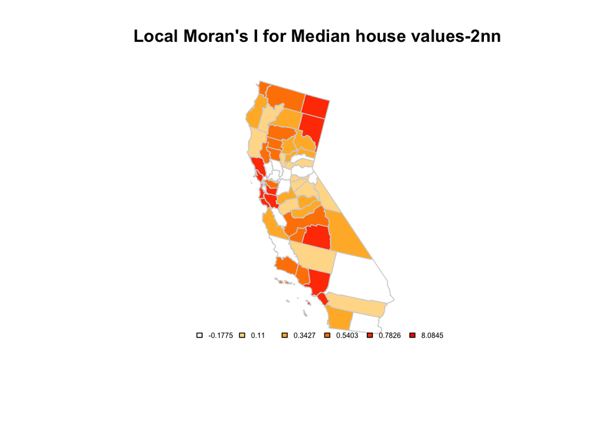

```r
socal$locM2<-(moranLochv2[,1])
morans_breaks2 <- quantile(socal$locM2,seq(0,1,1/5)) #quantile braks
col.palette <- colorRampPalette(c("white","orange", "red"), space = "rgb")
col_ramp2 <-col.palette(length(morans_breaks1))
# Statistically significant local Moran I as points
LocMoranTest2 = moranLochv2[,5]<=0.05
plot(nc_shp,border="lightgray",col=col_ramp2[findInterval(moranLochv2[,1],morans_breaks2,all.inside=TRUE)])
#points(soca_coords[,1][LocMoranTest2],ca_coords[,2][LocMoranTest2], col="blue", cex=0.5, pch=18)
legend("bottom",horiz=TRUE,legend=(round(morans_breaks1,digits=4)),fill=col_ramp2,bty='n',cex=0.5)
title("Local Moran's I for Median house values-2nn ")
```

```r
#4NN
moranLochv3<-localmoran(socal$median.house.values,ca_kn4_ww, p.adjust.method="bonferroni")
summary(moranLochv3)
```

```
##        Ii                E.Ii              Var.Ii            Z.Ii
##  Min.   :-0.38229   Min.   :-0.01754   Min.   :0.2236   Min.   :-0.7713
##  1st Qu.: 0.06404   1st Qu.:-0.01754   1st Qu.:0.2236   1st Qu.: 0.1725
##  Median : 0.29091   Median :-0.01754   Median :0.2236   Median : 0.6523
##  Mean   : 0.66502   Mean   :-0.01754   Mean   :0.2236   Mean   : 1.4435
##  3rd Qu.: 0.52987   3rd Qu.:-0.01754   3rd Qu.:0.2236   3rd Qu.: 1.1576
##  Max.   : 5.79118   Max.   :-0.01754   Max.   :0.2236   Max.   :12.2840
##    Pr(z > 0)
##  Min.   :0.0000
##  1st Qu.:0.6175
##  Median :1.0000
##  Mean   :0.7617
##  3rd Qu.:1.0000
##  Max.   :1.0000
```

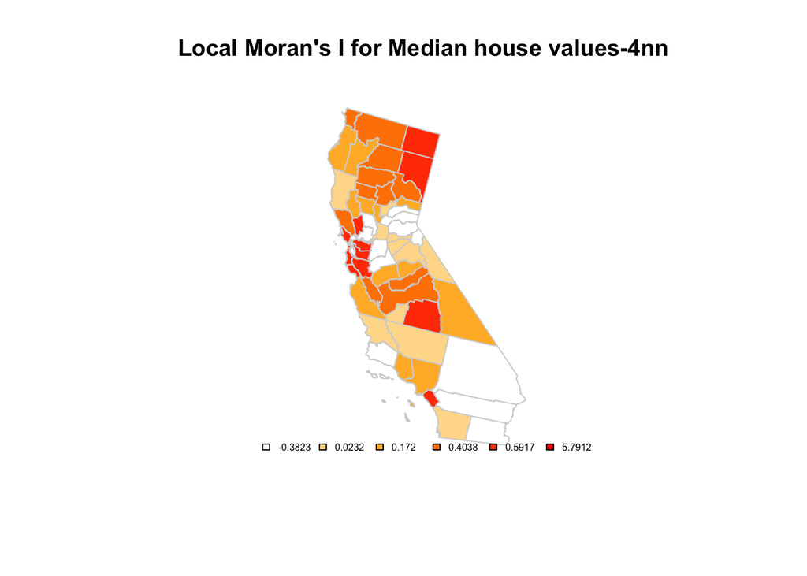

```r
socal$locM3<-(moranLochv3[,1])
morans_breaks3 <- quantile(socal$locM3,seq(0,1,1/5)) #quantile braks
col.palette <- colorRampPalette(c("white","orange", "red"), space = "rgb")
col_ramp3 <-col.palette(length(morans_breaks3))
# Statistically significant local Moran I as points
LocMoranTest3 = moranLochv3[,5]<=0.05
plot(nc_shp,border="lightgray",col=col_ramp3[findInterval(moranLochv3[,1],morans_breaks3,all.inside=TRUE)])
#points(soca_coords[,1][LocMoranTest3],ca_coords[,2][LocMoranTest3], col="blue", cex=0.5, pch=18)
legend("bottom",horiz=TRUE,legend=(round(morans_breaks3,digits=4)),fill=col_ramp3,bty='n',cex=0.5)
title("Local Moran's I for Median house values-4nn ")
```

### Autoregressive Models:

#### Simultaneous Autoregressive Models (SAR)

Median gross rent: For people with the same median age, there was a positive relationship between median gross rent and rent between 20-30% income. For people with the same median age, there was a positive relationship between median gross rent and rent between 40-50% income After adding race, the regression estimates were not significant and had a higher AIC. Therefore, the race variable was removed from the model. The parameter of spatial association $\rho$ was 0.56537.

```r
mod_sarlag = lagsarlm(median.gross.rent~Age+rentpctless10+rent1020+rent2030+rent3040+rent4050, data = socal,listw=ca_kn2_ww, zero.policy=T, tol.solve=1.0e-12)
summary(mod_sarlag)
```

```
##
## Call:lagsarlm(formula = median.gross.rent ~ Age + rentpctless10 +
##     rent1020 + rent2030 + rent3040 + rent4050, data = socal,
##     listw = ca_kn2_ww, zero.policy = T, tol.solve = 1e-12)
##
## Residuals:
##      Min       1Q   Median       3Q      Max
## -411.909 -139.737  -18.808  109.083  454.159
##
## Type: lag
## Coefficients: (asymptotic standard errors)
##                 Estimate Std. Error z value Pr(>|z|)
## (Intercept)   -2245.3066   742.3204 -3.0247 0.002489
## Age               9.4136     4.2218  2.2298 0.025764
## rentpctless10 16893.5170  9228.8079  1.8305 0.067172
## rent1020       1906.2935  1066.4661  1.7875 0.073859
## rent2030       4886.6904  1047.2726  4.6661 3.07e-06
## rent3040        997.1610   724.2296  1.3769 0.168556
## rent4050       2158.4222   865.6234  2.4935 0.012649
##
## Rho: 0.56537, LR test value: 28.672, p-value: 8.573e-08
## Asymptotic standard error: 0.086954
##     z-value: 6.502, p-value: 7.9252e-11
## Wald statistic: 42.276, p-value: 7.9252e-11
##
## Log likelihood: -385.7012 for lag model
## ML residual variance (sigma squared): 30395, (sigma: 174.34)
## Number of observations: 58
## Number of parameters estimated: 9
## AIC: 789.4, (AIC for lm: 816.07)
## LM test for residual autocorrelation
## test value: 19.364, p-value: 1.0803e-05
```

```r
socal$res_sarlag<-residuals(mod_sarlag)
```

Median house value: For people with the same median age, there was a positive relationship between median gross rent and rent between 20-30% income. After adding race, the regression estimates were not significant and had a higher AIC. Therefore, the race variable was removed from the model. The parameter of spatial association $\rho$ was 0.75601.

```r
#MEDIAN HOUSE VALUE
mod_sarlag2 <- lagsarlm(median.house.values~Age+rent1020+rent2030+rent3040+rent4050, data=socal, listw=ca_kn2_ww, zero.policy=T, tol.solve=1e-12)
summary(mod_sarlag2)
```

```
##
## Call:lagsarlm(formula = median.house.values ~ Age + rent1020 + rent2030 +
##     rent3040 + rent4050, data = socal, listw = ca_kn2_ww, zero.policy = T,
##     tol.solve = 1e-12)
##
## Residuals:
##        Min         1Q     Median         3Q        Max
## -171859.85  -61500.88    -175.68   41585.93  222373.16
##
## Type: lag
## Coefficients: (numerical Hessian approximate standard errors)
##              Estimate Std. Error z value  Pr(>|z|)
## (Intercept) -674095.3   336910.1 -2.0008 0.0454122
## Age            6249.2     2175.3  2.8728 0.0040683
## rent1020     300943.8   541845.1  0.5554 0.5786173
## rent2030    1865916.4   507406.4  3.6774 0.0002357
## rent3040    -285651.9   333581.2 -0.8563 0.3918213
## rent4050     274643.6   387783.0  0.7082 0.4787960
##
## Rho: 0.75601, LR test value: 60.059, p-value: 9.2149e-15
## Approximate (numerical Hessian) standard error: 0.059806
##     z-value: 12.641, p-value: < 2.22e-16
## Wald statistic: 159.8, p-value: < 2.22e-16
##
## Log likelihood: -752.4268 for lag model
## ML residual variance (sigma squared): 8132800000, (sigma: 90182)
## Number of observations: 58
## Number of parameters estimated: 8
## AIC: 1520.9, (AIC for lm: 1578.9)
```

```r
socal$res_sarlag2<-residuals(mod_sarlag2)
```

#### Conditional Autoregressive Models (CAR)

Median gross rent: For people with the same median age, there was a positive relationship between median gross rent and rent between 10- 20%. For people with the same median age, there was a positive relationship between median gross rent 20-30%. For people with the same median age, there was a positive relationship between median gross rent 30-40%. For people with the same median age, there was a positive relationship between median gross rent rent between 40-50% income. After adding race, the regression function was not significant and had a higher AIC. Therefore, race was removed from the model. Lambda: 0.6182.

```r
car_mr<-spautolm(median.gross.rent~Age+rent1020+rent2030+rent3040+rent4050, data = socal,listw=ca_kn2_ww, zero.policy=T, tol.solve=1e-12,family="CAR")
summary(car_mr)
```

```
##
## Call: spautolm(formula = median.gross.rent ~ Age + rent1020 + rent2030 +
##     rent3040 + rent4050, data = socal, listw = ca_kn2_ww, family = "CAR",
##     zero.policy = T, tol.solve = 1e-12)
##
## Residuals:
##      Min       1Q   Median       3Q      Max
## -601.163 -131.154  -28.341  139.798  793.033
##
## Coefficients:
##               Estimate Std. Error z value  Pr(>|z|)
## (Intercept) -3381.6770   942.2449 -3.5890  0.000332
## Age            12.6217     6.6411  1.9005  0.057363
## rent1020     3185.4849  1451.4438  2.1947  0.028185
## rent2030     7014.1059  1254.4264  5.5915 2.251e-08
## rent3040     2630.1325   871.5032  3.0179  0.002545
## rent4050     4425.6310  1044.3175  4.2378 2.257e-05
##
## Lambda: 0.6182 LR test value: 11.94 p-value: 0.00054931
## Numerical Hessian standard error of lambda: NaN
##
## Log likelihood: -400.7206
## ML residual variance (sigma squared): 53833, (sigma: 232.02)
## Number of observations: 58
## Number of parameters estimated: 8
## AIC: 817.44
```

```r
socal$res_car<-residuals(car_mr)
```

```r
car_mr2<-spautolm(median.house.values~Age+rent2030+rent3040+rent4050+Whitepct+blackpct+Asianpct, data = socal,listw=ca_kn2_ww, zero.policy=T, tol.solve=1e-12,family="CAR")
summary(car_mr2)
```

```
##
## Call: spautolm(formula = median.house.values ~ Age + rent2030 + rent3040 +
##     rent4050 + Whitepct + blackpct + Asianpct, data = socal,
##     listw = ca_kn2_ww, family = "CAR", zero.policy = T, tol.solve = 1e-12)
##
## Residuals:
##     Min      1Q  Median      3Q     Max
## -495003 -125361  -12698   92298  267921
##
## Coefficients:
##                Estimate  Std. Error  z value  Pr(>|z|)
## (Intercept)  7.1836e+05  1.7757e+02   4045.6 < 2.2e-16
## Age          1.0895e+04  2.9093e+00   3745.1 < 2.2e-16
## rent2030    -1.1025e+06  4.1135e+02  -2680.3 < 2.2e-16
## rent3040    -2.4231e+06  3.1914e+02  -7592.5 < 2.2e-16
## rent4050    -2.6085e+06  2.4425e+02 -10679.6 < 2.2e-16
## Whitepct    -2.4768e+05  2.3674e+02  -1046.2 < 2.2e-16
## blackpct    -7.2333e+05  5.6657e+02  -1276.7 < 2.2e-16
## Asianpct    -1.7225e+06  3.0003e+02  -5741.0 < 2.2e-16
##
## Lambda: 0.99082 LR test value: 823.78 p-value: < 2.22e-16
## Numerical Hessian standard error of lambda: NaN
##
## Log likelihood: -349.494
## ML residual variance (sigma squared): 6564.7, (sigma: 81.023)
## Number of observations: 58
## Number of parameters estimated: 10
## AIC: 718.99
```

```r
socal$res_car2<-residuals(car_mr2)
```

## Conclusion

In this project, we used KNN nearest neighbor to investigate the spatial autocorrelation for median rent and median house value variables and we found statistically significant clustering in the bay area. When we used 4NN, southern California was also found significant clustering effects. spatial autoregressive models to investigate the association between age, race, median rent, rent as a percentage of income separately for the median rent and median house value. After comparing the results of the SAR model and CAR model,the SAR provided a better prediction for median gross rent, and the CAR model provided a better prediction for the median house value.